# Gradient Boosting Practice Problems

### Problem 1

Given the data.

| X | y |
| --- | --- |
| 1 | 1 |
| 2 | 0 |
| 3 | 2 |

We will train a gradient boosted tree (stump) on this data with the learning rate of 1.

1. Calculate the prediction of the first round.
2. Calculate the target of the second round
3. Suppose that the stump in the second round is: $X>2.5$. Calculate the predictions of the second round. What do the second round predict?
4. What are the final predictions of the gradient boosting model for $y$ in the training data after the second round?
5. Calculate the target of the third round.
6. Suppose that the stump in the third round is: $X>1.5$. Calculate the predictions of the third round. What do the third round predict?
7. What are the final predictions of the gradient boosting model for $y$ in the training data after the third round?

## Solution

1. The prediction of the first round is just the average of $y$.

|  | X | Y | Pred1 |
| --- | --- | --- | --- |
| 0 | 1 | 1 | 1 |
| 1 | 2 | 0 | 1 |
| 2 | 3 | 2 | 1 |

2. The target of the second round is the errors of the first round.

|  | X | Y | Pred1 | e1 |
| --- | --- | --- | --- | --- |
| 0 | 1 | 1 | 1 | 0 |
| 1 | 2 | 0 | 1 | -1 |
| 2 | 3 | 2 | 1 | 1 |

3. The second round predicts the errors of the first round ($e1$).

Since the stump is $X>2.5$, we have the following predictions of the second round (Pred2)

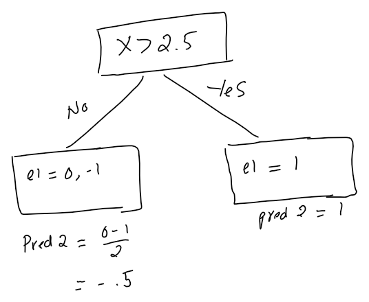

Thus, we have the following table.

|  | X | Y | Pred1 | e1 | Pred2 |
| --- | --- | --- | --- | --- | --- |
| 0 | 1 | 1 | 1 | 0 | -0.5 |
| 1 | 2 | 0 | 1 | -1 | -0.5 |
| 2 | 3 | 2 | 1 | 1 | 1 |

|  | X | Y | Pred1 | Pred2 | Prediction of $y$ |
| --- | --- | --- | --- | --- | --- |
| 0 | 1 | 1 | 1 | -0.5 | 0.5 |
| 1 | 2 | 0 | 1 | -0.5 | 0.5 |
| 2 | 3 | 2 | 1 | 1 | 2 |

|  | X | Y | Pred1 | e1 | Pred2 | e2 |
| --- | --- | --- | --- | --- | --- | --- |
| 0 | 1 | 1 | 1 | 0 | -0.5 | 0.5 |
| 1 | 2 | 0 | 1 | -1 | -0.5 | -0.5 |
| 2 | 3 | 2 | 1 | 1 | 1 | 0 |

6. The third round predicts the errors of the secon round.

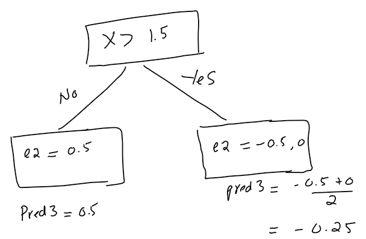

Thus, we have:

|  | X | Y | Pred1 | e1 | Pred2 | e2 | Pred3 |
| --- | --- | --- | --- | --- | --- | --- | --- |
| 0 | 1 | 1 | 1 | 0 | -0.5 | 0.5 | 0.5 |
| 1 | 2 | 0 | 1 | -1 | -0.5 | -0.5 | -0.25 |
| 2 | 3 | 2 | 1 | 1 | 1 | 0 | -0.25 |

7. The predictions of $y$ after the third round is the summation of the first round predictions, the second round predictions and the third round predictions (Pred1+Pred2+Pred3). Therefore, we have:

|  | X | Y | Pred1 | Pred2 | Pred3 | Pred_Final |
| --- | --- | --- | --- | --- | --- | --- |
| 0 | 1 | 1 | 1 | -0.5 | 0.5 | 1 |
| 1 | 2 | 0 | 1 | -0.5 | -0.25 | 0.25 |
| 2 | 3 | 2 | 1 | 1 | -0.25 | 1.75 |